# An Introduction to Statistical Learning

## Assessing Model Accuracy

### Jan Geissbauer

### October 17, 2018

### Topics

- Introduction
- Measuring the Quality of Fit
- The Bias-Variance Trade-Off
- The Classification Setting

### Introduction

“No free lunch in statistics”

- No method dominates all others over all possible data sets
- Important task: decide which method produces the best results
- We discuss concepts for selecting a statistical learning procedure

### Measuring the Quality of Fit

- Performance of a statistical learning method
- How close is the prediction to the observed data?

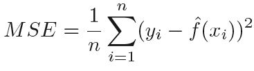

- Training MSE works for training data
- But we are interested in the accuracy of the predictions

What can we do?

- If we have access to observations, not used for training:
- calculate the MSE and select the learning method with smallest test MSE

But what if no test observations are available?

- Problem: training and test MSE can be quite different!

Some practical solutions will be discussed throughout this book

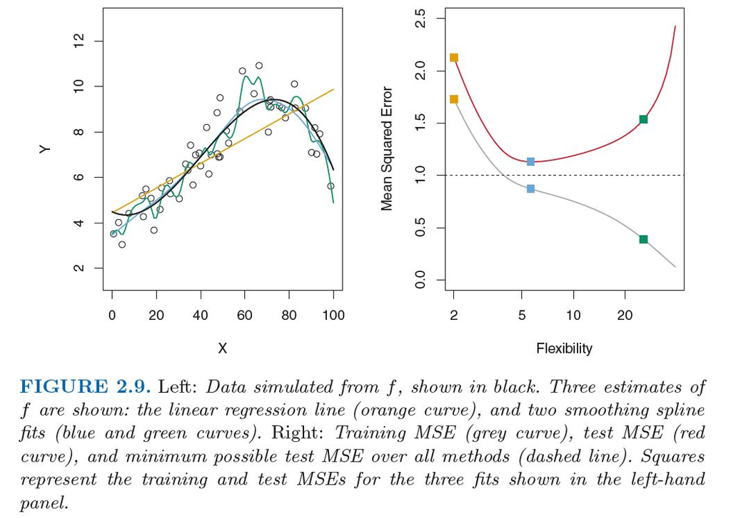

Source: G. James, D. Witten, T. Hastie and R. Tibshirani: *An Introduction to Statistical Learning*

### The Bias-Variance Trade-Off

Decomposition of the expected test MSE, for a given value:

- the variance
- the squared bias
- the variance of the error terms

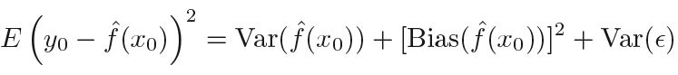

### Variance

the amount by which our model would change by using different training data sets

more flexible methods have higher variance

### Bias

the amount indicating how well the model fits the training data

more flexible methods result in less bias

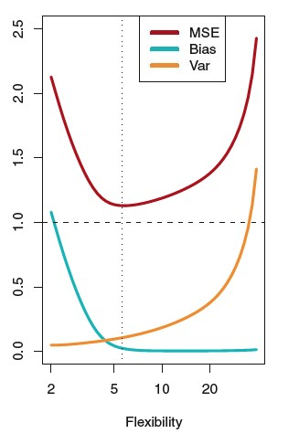

Source: G. James, D. Witten, T. Hastie and R. Tibshirani: *An Introduction to Statistical Learning*

By increasing the flexibility:

Bias initially decreases faster than the variance increases  
*expected test MSE declines*

At some point, small bias and significantly increasing variance *expected test MSE grows*

Typical U-shaped MSE

In order to minimize the MSE we need **a method** that simultaneously achieves **low variance** and **low bias**

### The Classification Setting

### Training Error

### Test error

A good classifier is one for which the test error is smallest!

### Bayes Classifier

Minimizing the test error rate (on average):

Assigning observations to the most likely class

Bayes error rate:

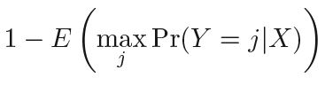

Bayes decision boundary: separates the classes

### K-Nearest Neighbors (KNN)

Actualy we do not know the conditional distribution of Y given X, therefore:

Bayes Classifier serves as unattainable gold standard

What can we do? Solution:

- Given an positive integer K and a test observation x\( _0 \)
- KNN identifies the K points in the training data closest to x\( _0 \)
- it estimates the conditional probability for class j
- then KNN classifies x\( _0 \) to the class with the largest probability

Number of K corresponds with the flexibility of the classifier

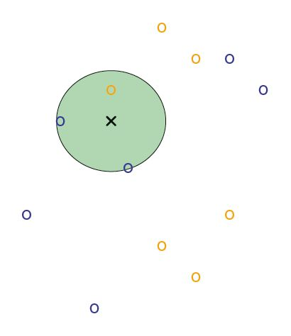

Source: G. James, D. Witten, T. Hastie and R. Tibshirani: *An Introduction to Statistical Learning*